Zijing Cheng(Mavis, zc233)

# Exploring data

### In this part, I will do some exploration on the cleaned data

### First, it is about the text data

```python
import pandas as pd
                        t = pd.read_csv("textcleaning_py.csv")
```

```python
t.head()
```

|  | id | retweet_count | retweeted | Clean_Text |
| --- | --- | --- | --- | --- |
| 0 | 1570097774930132992 | 1060 | True | rt nickiminaj let hope ppl guy r dirty work lo... |
| 1 | 1570097774355709954 | 0 | False | ciaoszn charity work ☺ ️ ☺ ️ ☺ ️ |
| 2 | 1570097773839630337 | 53 | True | rt marii_chaudhry congratulations team wepatri... |
| 3 | 1570097773697015808 | 179 | True | rt fact not wish work |
| 4 | 1570097773672042498 | 161 | True | rt jeonmanwon seungcheol suspicious like puppe... |

### Word Cloud

```python
import wordcloud
```

```python
w = wordcloud.WordCloud(width=1000,
                                                height=700,
                                                background_color='white')
```

```python
a = ""
                        for i in range(100):
                            new = t.Clean_Text[i]
                            a = a+" "+new
```

```python
w.generate(a)
```

```
<wordcloud.wordcloud.WordCloud at 0x7fd1bc879de0>
```

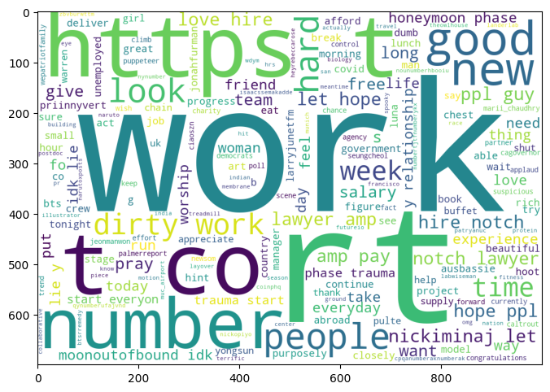

```python
import matplotlib.pyplot as plt
                        plt.figure(figsize = (8, 8), facecolor = None)
                        plt.imshow(w)
                        plt.show()
```

### The above picture is a word cloud. First, a word cloud is a visual representation, an image, of word data. In other words, it is a collection, or cluster, of words depicted in different sizes. The bigger and bolder the word appears, the more often it’s mentioned within a given text and the more important it is. As we can see in the above picture, we can see that the word "work" is the biggest one, as it is obvious, since we use it as our keyword to search in Twitter.

### Also, we can find that "good", "hope","new", which are more likely to indicate positive attitudes while, there is "dirty", which is more likely to indicate negative attitudes. This picture can give us a rough look of text data.

### Second, it is about our quantitive and qualitative data

```python
q = pd.read_csv("cleaned_data_r.csv")
```

```python
q["id"] = q["id"].apply(str)
                        q = q.drop(q.columns[0], axis = 1)
```

```python
q.describe()
```

|  | retweet_count | favorite_count | followers_count | friends_count | favourites_count |
| --- | --- | --- | --- | --- | --- |
| count | 100.000000 | 100.0 | 100.000000 | 100.000000 | 100.000000 |
| mean | 1037.890000 | 0.0 | 3.160000 | 3.320000 | 3.480000 |
| std | 3016.959386 | 0.0 | 2.427619 | 2.481772 | 2.439076 |
| min | 0.000000 | 0.0 | 0.000000 | 0.000000 | 0.000000 |
| 25% | 0.000000 | 0.0 | 1.000000 | 1.000000 | 1.000000 |
| 50% | 3.500000 | 0.0 | 2.000000 | 2.500000 | 3.000000 |
| 75% | 165.500000 | 0.0 | 5.000000 | 5.000000 | 5.000000 |
| max | 19560.000000 | 0.0 | 9.000000 | 9.000000 | 9.000000 |

### From the above summary, we can find that the variability of retweet_count very big. If a variable has a higher standard deviation, it signifies that the values spread out further from the mean. And we can find the averages of number of followers and friends are small but the mean of retweet_count is more than 1,000 pieces. So we can further explore more on why some people with low friends but have high retweet count.

## Histogram

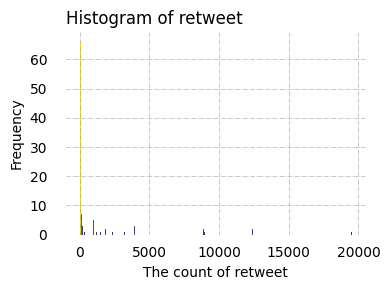

```python
import matplotlib.pyplot as plt
                        import numpy as np
                        from matplotlib import colors
                        from matplotlib.ticker import PercentFormatter

                        # Creating histogram to further customerize
                        fig, axs = plt.subplots(1, 1,
                                                figsize =(4, 3),
                                                tight_layout = True)
                        # Remove axes splines
                        for s in ['top', 'bottom', 'left', 'right']:
                            axs.spines[s].set_visible(False)
                        # Remove x, y ticks
                        axs.xaxis.set_ticks_position('none')
                        axs.yaxis.set_ticks_position('none')
                        # Add padding between axes and labels
                        axs.xaxis.set_tick_params(pad = 5)
                        axs.yaxis.set_tick_params(pad = 10)
                        # Add x, y gridlines
                        axs.grid(visible = True, color ='grey',
                                linestyle ='-.', linewidth = 0.5,
                                alpha = 0.6)
                        # Creating histogram
                        N,bins, patches = axs.hist(q["retweet_count"], bins = "auto")
                        # Setting color
                        fracs = ((N**(0.5)))
                        norm = colors.Normalize(fracs.min(), fracs.max())
                        for frac, patch in zip(fracs, patches):
                            color = plt.cm.viridis(norm(frac))
                            patch.set_facecolor(color)
                        # Adding extra features
                        plt.xlabel("The count of retweet")
                        plt.ylabel("Frequency")
                        plt.title('Histogram of retweet',loc = "left")

                        # Show plot
                        plt.show()
```

### As the data is small, since I didn't use all the data, we can not see the complete distribution of retweet_count. But we can find that, the most retweet_count are focus on [0,200]. As the count of retweet becomes larger, the frequency is smaller. The distribution of retweet_count is right skewed, which means that the most of data focus on the left side and the shape of this distribution is high and sharp.

## Scatter Plot

```python
x = q["retweet_count"]
                        y1 = q["friends_count"]
                        y2 = q["followers_count"]
```

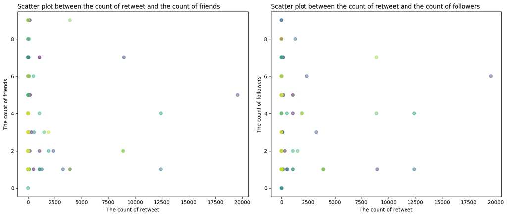

```python
import matplotlib.pyplot as plt
                        import numpy as np
                        fig, axes = plt.subplots(1, 2,
                                                figsize =(14, 6),
                                                tight_layout = True)
                        N = 100
                        #colors = np.random.rand(N)+10
                        colors = np.array(range(N))
                        axes[0].scatter(x,y1,c=colors,alpha = 0.5,cmap='viridis')
                        axes[1].scatter(x,y2,c=colors,alpha = 0.5,cmap='viridis')
                        axes[0].set_title('Scatter plot between the count of retweet and the count of friends',loc = "left")
                        axes[1].set_title('Scatter plot between the count of retweet and the count of followers',loc = "left")
                        axes[0].set_xlabel("The count of retweet")
                        axes[1].set_xlabel("The count of retweet")
                        axes[0].set_ylabel("The count of friends")
                        axes[1].set_ylabel("The count of followers")
                        fig.tight_layout()


                        plt.show()
```

## Boxplot

```python
q
```

|  | id | truncated | retweet_count | favorite_count | favorited | retweeted | lang | followers_count | friends_count | favourites_count | has_extended_profile |
| --- | --- | --- | --- | --- | --- | --- | --- | --- | --- | --- | --- |
| 0 | 1.5700977749301327e+18 | False | 1060 | 0 | False | False | en | 5 | 7 | 8 | True |
| 1 | 1.57009777435571e+18 | False | 0 | 0 | False | False | en | 1 | 2 | 2 | True |
| 2 | 1.5700977738396303e+18 | False | 53 | 0 | False | False | en | 1 | 7 | 1 | True |
| 3 | 1.5700977736970158e+18 | False | 179 | 0 | False | False | en | 5 | 5 | 1 | True |
| 4 | 1.5700977736720425e+18 | False | 161 | 0 | False | False | en | 7 | 9 | 2 | True |
| ... | ... | ... | ... | ... | ... | ... | ... | ... | ... | ... | ... |
| 95 | 1.5700977507918395e+18 | False | 0 | 0 | False | False | en | 8 | 3 | 3 | True |
| 96 | 1.5700977507207864e+18 | False | 3 | 0 | False | False | en | 2 | 4 | 1 | False |
| 97 | 1.5700977501461747e+18 | False | 1 | 0 | False | False | en | 3 | 2 | 5 | True |
| 98 | 1.5700977500453478e+18 | False | 6 | 0 | False | False | en | 3 | 3 | 3 | False |
| 99 | 1.5700977498022584e+18 | False | 4 | 0 | False | False | en | 5 | 1 | 2 | True |

100 rows × 11 columns

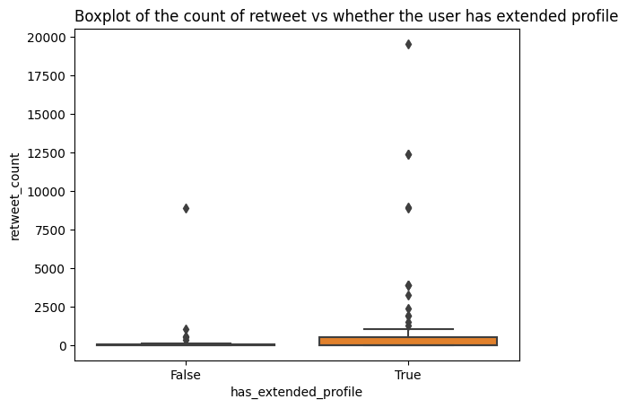

```python
import seaborn as sns
                        data = pd.concat([q["has_extended_profile"],q["retweet_count"]],axis = 1)
                        # use seanborn to plot boxplot
                        sns.boxplot(y = "retweet_count",x="has_extended_profile",data = data)
                        # set title
                        plt.title("Boxplot of the count of retweet vs whether the user has extended profile",loc="left")
                        plt.show()
```

### From above boxplot, we can find that boxplots between two groups, has extended profile and does not have extended profile, have big difference. And the average of retweet of having extended profile is larger than that of not having extended profile. As for extreme points, the extreme points in the group of not having extended profile is much less than that of another group. This is following our intuition, as there is many robots in Twitter, when some take Twitter serious, they always to extend their profile, so that the tweets of these people can be more attractive.

### Email

zc233@georgetown.edu